# Exploration of Loan Data from Prosper by Yajie ZHU

The dataset in this report contains 113,937 loans with 81 variables on each loan, including loan amount, borrower rate (or interest rate), current loan status, borrower income, borrower employment status, borrower credit history, and the latest payment information.

# 1 Data Checking Section

## 1.1 Check Repeated Records

There are 113937 rows in this dataset while the number of the unique value of `ListingKey` is only 113066 (less than the number of the rows), which should be checked before further analysis.

So I checked the count of each ListingKey and show the top 5 ListingKeys below which appear more than once in the dataset:

```
## # A tibble: 5 x 2
##                ListingKey     n
##                     <chr> <int>
## 1 17A93590655669644DB4C06     6
## 2 349D3587495831350F0F648     4
## 3 47C1359638497431975670B     4
## 4 8474358854651984137201C     4
## 5 DE8535960513435199406CE     4
```

For the ListingKey (“17A93590655669644DB4C06”) which appears six times in the dataset, I checked all the six records and found that the `ProsperScore` column is different among these records. However, this is the only difference exists in the data and I think there should be an addtional column which indicates when the `ProsperScore` was changed.

Anyway, there are no repeated records for ListingKey (“17A93590655669644DB4C06”) so no further action is necessary to be taken. Furthermore, after run the code `unique(dat) %>% dim()` it seems that there are no repeated records in the whole dataset.

## 1.2 Check Missing Data

It’s an important step to check the missing value in the dataset and decide whether the missing data will affect the analysis significantly before performing any analysis. So I calculated the ratio of missing value for each column of this dataset and printed the columns of which the missing data is more than 20% in the below table:

```
## # A tibble: 18 x 2
##                                    col     ratio
##                                  <chr>     <dbl>
##  1                            GroupKey 0.8829090
##  2       LoanFirstDefaultedCycleNumber 0.8512160
##  3         ScorexChangeAtTimeOfListing 0.8338731
##  4                   TotalProsperLoans 0.8061648
##  5          TotalProsperPaymentsBilled 0.8061648
##  6               OnTimeProsperPayments 0.8061648
##  7 ProsperPaymentsLessThanOneMonthLate 0.8061648
##  8     ProsperPaymentsOneMonthPlusLate 0.8061648
##  9            ProsperPrincipalBorrowed 0.8061648
## 10         ProsperPrincipalOutstanding 0.8061648
## 11                         CreditGrade 0.7458859
## 12                          ClosedDate 0.5164960
## 13             EstimatedEffectiveYield 0.2552639
## 14                       EstimatedLoss 0.2552639
## 15                     EstimatedReturn 0.2552639
## 16             ProsperRating (numeric) 0.2552639
## 17               ProsperRating (Alpha) 0.2552639
## 18                        ProsperScore 0.2552639
```

At first it looks like that there are 18 variables whose missing data is more than 20%, however, after reading the data variables definitions, it turns out the `NA` value for each of these variables has its specific meaning, which means they are not really the “missing value”. Therefore, I believe that this is probably a clean dataset and it’s time to play with the data!

# 2 Univariate Plots Section

## 2.1 Ask the Questions

For the Univariate Plots Section, I choose the following questions to explore in this project:

1. What’s the date period of this dataset?
2. What’s the distribution of the category of the listing that the borrower selected when posting their listing?
3. What’s the percentage of each LoanStatus in this dataset?
4. What’s the percentage of each EmploymentStatus in this dataset?
5. What’s the distribution of EmploymentStatusDuration in this dataset?
6. What’s the percentage of the Homeowner in the Borrowers?
7. What’s the percentage of the defaulted loans and what’s the distribution of the cycle of these defaulted loans?
8. What’s the distribution of ProsperScore in this dataset?

## 2.2 What’s the date period of this dataset?

At the first of all, I would like to check the time period of this dataset:

```
##                  Min.               1st Qu.                Median
## "2005-11-09 20:44:28" "2008-09-19 10:02:14" "2012-06-16 12:37:19"
##                  Mean               3rd Qu.                  Max.
## "2011-07-09 08:07:23" "2013-09-09 19:40:48" "2014-03-10 12:20:53"
```

The time period of this dataset is from 2005-11-09 to 2014-03-10.

## 2.3 What’s the distribution of the category of the listing?

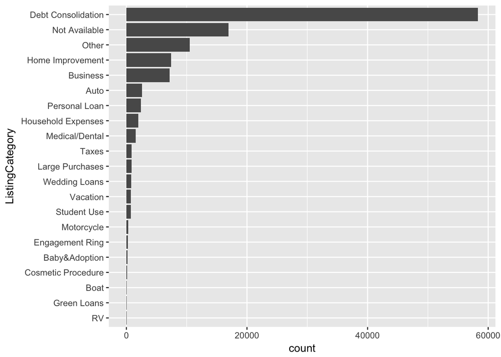

It’s interesting to see that the most popular ListingCategory is “Debt Consolidation”, which looks like morn than the sum of all the other types. The second and third popular ListingCategory are “Not Available” and “Other”, which provides little effective information about the usage of the debt.

## 2.4 What’s the percentage of each LoanStatus?

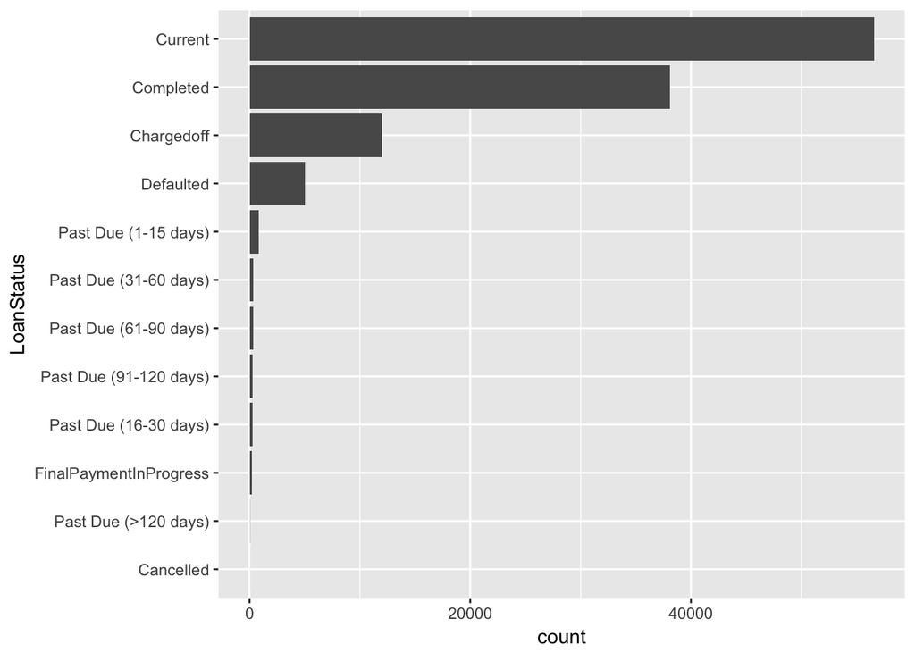

However, the number of the “Chargedoff” loans is 11992 and the number of the “Defaulted” loans is 5018, which means the default risk is high and should be addressed by the investors (Loans of Chargedoff status and Defaulted status stand for 14.93% of the total loans).

## 2.5 What’s the percentage of each EmploymentStatus?

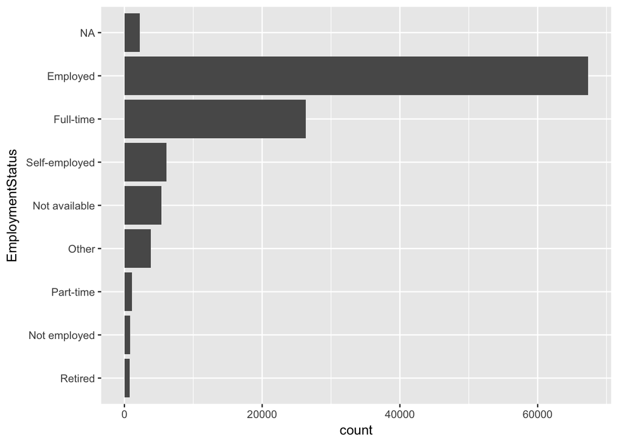

There is no surprise that the majority of the borrowers have a job, because people with no job have difficulties to obtian the loans.

## 2.6 What’s the distribution of EmploymentStatusDuration?

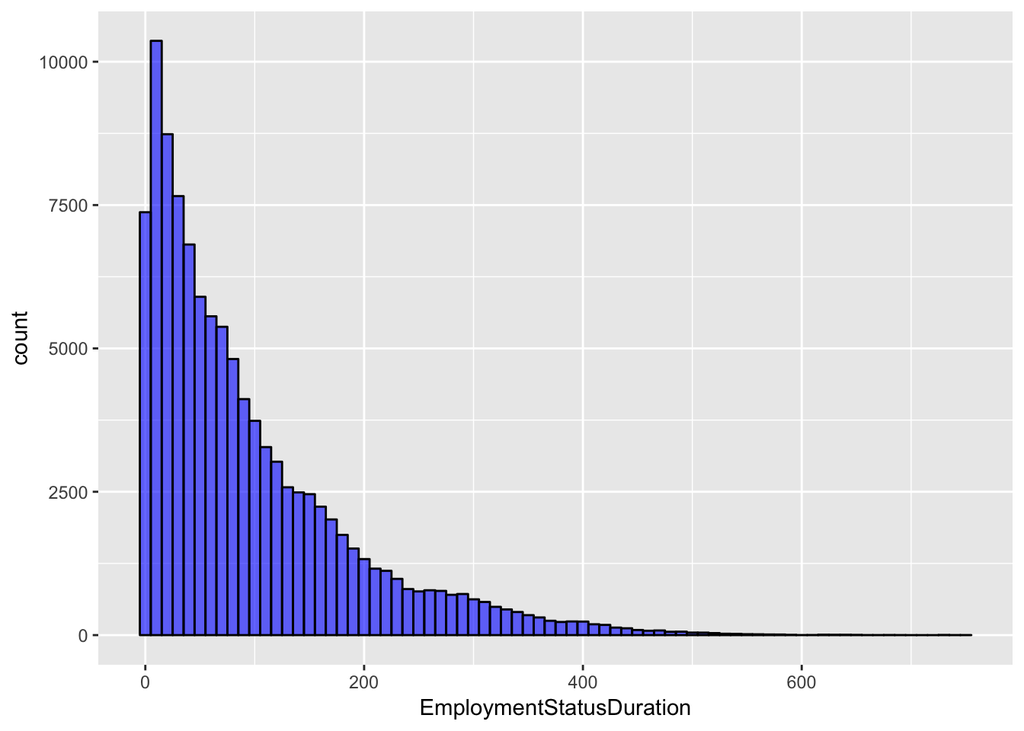

```
##    Min. 1st Qu.  Median    Mean 3rd Qu.    Max.    NA's
##    0.00   26.00   67.00   96.07  137.00  755.00    7625
```

The figure above shows that the distribution of EmploymentStatusDuration is positive skewed, and the summary of EmploymentStatusDuration shows that about one quarter have more than 10 years of employment, and about one half have more than 5 years of employment.

## 2.7 What’s the percentage of the Homeowner in the Borrowers?

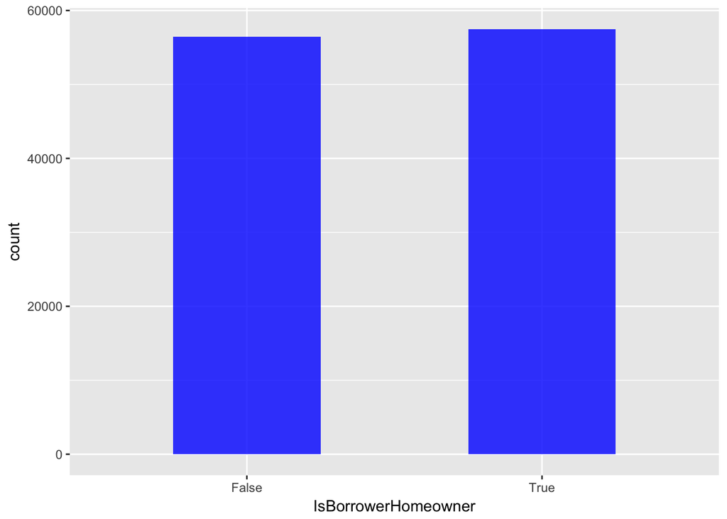

It shows that the percentage of the homeowner in the borrowers is about one half.

## 2.8 What’s the percentage of the defaulted loans?

The data variable definitions show that for the “LoanFirstDefaultedCycleNumber” column: If the loan has not charged off the value will be null. So we can use this variable to compute the percentage of the defaulted loans, which is 14.88%.

## 2.9 What’s the distribution of the cycle of these defaulted loans?

Furthermore, the distribution of the cycle of these defaulted loans may reveal more information:

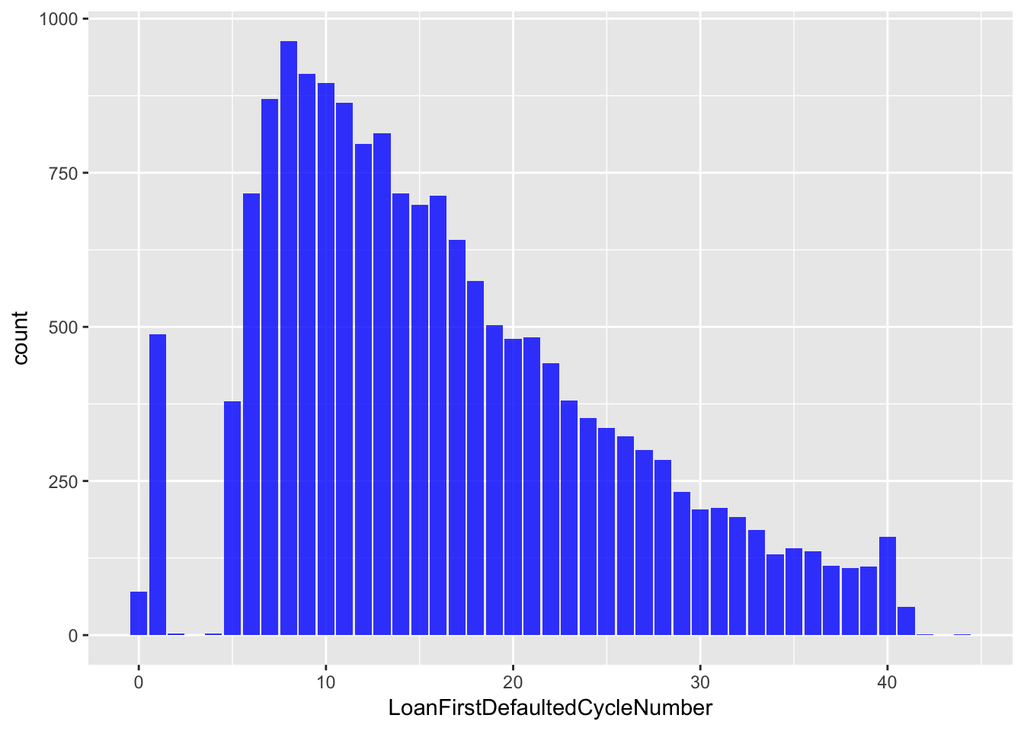

It’s interesting to find that if default didn’t occur in the first two cycles, then it’s unlikely to occur in the following three cycles.

## 2.10 What’s the distribution of ProsperScore?

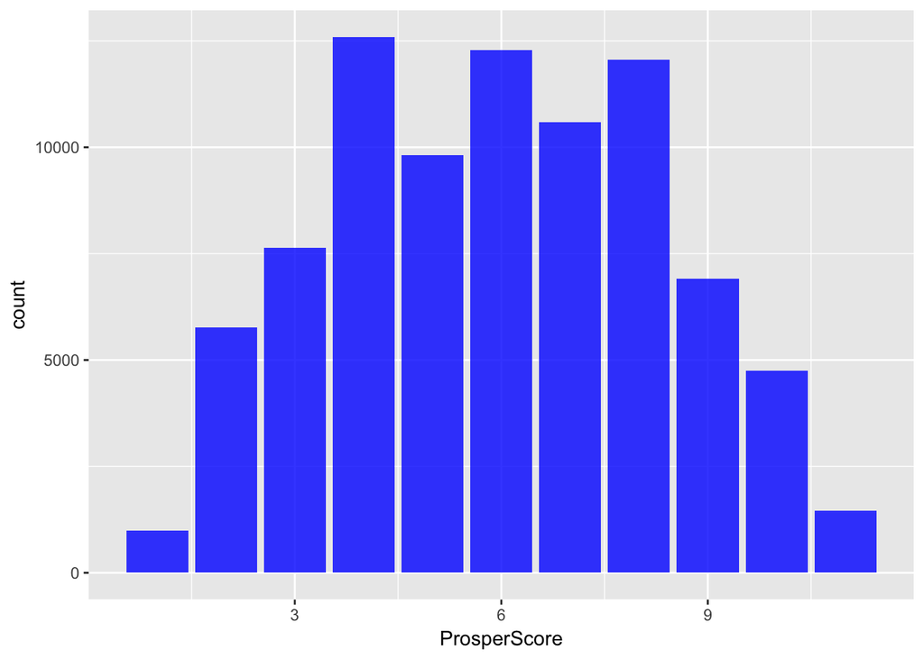

The distribution of ProsperScore looks like a normal distribution while the top 3 most frequently ProsperScores are 4, 6, and 8, and the top 2 least frequently ProsperScores are 1 and 11. However, the data varibale definitions show that the ProsperScore ranges from 1-10, with 10 being the best, or lowest risk score. So I decide to double check the ProsperScore field:

```
## # A tibble: 1 x 2
##   ProsperScore     n
##          <dbl> <int>
## 1           11  1456
```

**It seems like that there are 1456 rows of which the ProsperScore equals 11, but 11 is not a valid score based on the data varibale definitions. So I suspect that this maybe a data error or something else, which need to be investigated in the further analysis.**

# 3 Univariate Analysis

## 3.1 What is the structure of your dataset?

There are 113,937 loans with 81 variables including loan amount, borrower rate (or interest rate), current loan status, borrower income, borrower employment status, borrower credit history, and the latest payment information in this dataset.

There are so many variables in this dataset so it is difficult to explore each variable one by one. Instead, it woule be more appropriate to adopt a problem-oriented approach to explore this dataset. Actually I used this approach in this project.

## 3.2 What is/are the main feature(s) of interest in your dataset?

The main features of interest in this dataset are:

1. `LoanFirstDefaultedCycleNumber`;
2. `ProsperScore`, `ProsperRating (Alpha)`, `ProsperRating (numeric)`;
3. `CreditScoreRangeLower`, `CreditScoreRangeUpper`.

I choose these features as the main features because for the loan business, the most important concern is the credit/default risk. For the creditor/lender, what they most want to forecast is whether the borrower will default on the loan and when the borrower will most likely default.

## 3.3 What other features in the dataset do you think will help support your investigation into your feature(s) of interest?

Of the six main features of interest described above, I choose `LoanFirstDefaultedCycleNumber` as the target feature, and try to use `ProsperScore`, `ProsperRating (Alpha)`, `ProsperRating (numeric)`, `CreditScoreRangeLower`, `CreditScoreRangeUpper` as well as other features to predict whether the borrower will default and when the borrower will most likely default.

## 3.4 Did you create any new variables from existing variables in the dataset?

For the Univariate Plots Section, I didn’t create new variables from existing variables, but I did modify some variables (such as changing the factor levels or reorder the factor) in order to make better visualisations.

## 3.5 Of the features you investigated, were there any unusual distributions?

Of the features you investigated EmploymentStatusDuration and LoanFirstDefaultedCycleNumber don’t follow normal distribution and both of them are positive skewed.

**Did you perform any operations on the data to tidy, adjust, or change the form of the data? If so, why did you do this?**

As I mentioned before, I modify some variables (such as changing the factor levels or reorder the factor) in order to make better visualisations.

# 4 Bivariate Plots Section

1. What’s the distribution of IncomeRange of the Borrowers (only for the group have verifiable income)?
2. What’s the distribution of StatedMonthlyIncome of the Borrowers (only for the group have verifiable income)?

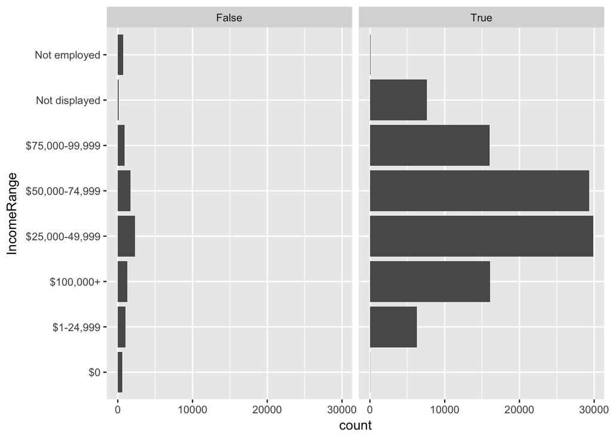

[figure not shown]

[output not shown]

# 5 Bivariate Analysis

### 5.0.1 Talk about some of the relationships you observed in this part of the investigation. How did the feature(s) of interest vary with other features in the dataset?

### 5.0.2 Did you observe any interesting relationships between the other features (not the main feature(s) of interest)?

### 5.0.3 What was the strongest relationship you found?

# 6 Multivariate Plots Section

# 7 Multivariate Analysis

### 7.0.1 Talk about some of the relationships you observed in this part of the investigation. Were there features that strengthened each other in terms of looking at your feature(s) of interest?

### 7.0.2 Were there any interesting or surprising interactions between features?

### 7.0.3 OPTIONAL: Did you create any models with your dataset? Discuss the strengths and limitations of your model.

# 8 Final Plots and Summary

### 8.0.1 Plot One

### 8.0.2 Description One

### 8.0.3 Plot Two

### 8.0.4 Description Two

### 8.0.5 Plot Three

### 8.0.6 Description Three

# 9 Reflection